# DATA3888 Discipline Assessment 2

- Show All Code
- Hide All Code
- View Source

Stock Volatility Modeling

Author

520326356

Published

April 7, 2025

# Future Stock Volatility Prediction

This project is aimed at build an interpretable model to predict the future volatility of a stock. Multiple models are developed, including Linear Regression, HAR, HAV-RV and GARCH. These models are then evaluated using standard performance metrics to identify which provides the most reliable volatility predictions. But first, let’s load the required packages.

```r
library(ggplot2)
library(dplyr)
library(rugarch)
library(zoo)
library(tidyverse)
```

## Data Processing

The data used in this project is `stock_1`, which contains high-frequency trading data. The dataset contains 1507532 rows and 11 columns of data.

```r
stock1 <- read.csv("stock_1.csv")
dim(stock1)
```

```
[1] 1507532      11
```

```r
head(stock1)
```

```
  time_id seconds_in_bucket bid_price1 ask_price1 bid_price2 ask_price2
1       5                 0   1.000754   1.001542   1.000689   1.001607
2       5                 1   1.000754   1.001673   1.000689   1.001739
3       5                 2   1.000754   1.001411   1.000623   1.001476
4       5                 3   1.000754   1.001542   1.000689   1.001607
5       5                 4   1.000754   1.001476   1.000623   1.001542
6       5                 5   1.000754   1.001542   1.000623   1.001673
  bid_size1 ask_size1 bid_size2 ask_size2 stock_id
1         1        25        25       100        1
2        26        60        25       100        1
3         1        25        25       125        1
4       125        25       126        36        1
5       100       100        25        25        1
6       100        25        25        60        1
```

### Calculate Key Variables

Once the dataset is loaded, the key variable `BidAskSpread` is computed to measure liquidity. Using bid and ask prices and sizes, we also calculate the Weighted Average Price (WAP). With WAP, it provides a more accurate estimate of the fair price by weighting the sizes of bid and ask prices. This prevents the traders from just relying on the last trade price. These metrics are calculated because they are commonly used in high-frequency trading and financial modelling. They are also calculated to assess fair stock prices and evaluate liquidity. Then, these key variables are added to `stock1` data.

$WAP =\frac{(bid\_price1 * ask\_size1) + (ask\_price1 * bid\_size1)}{bid\_size1 + ask\_size1}$

$BidAskSpread={\frac{ask\_price1}{bid\_price1}-1}$

```r
stock1 <- stock1 %>% mutate(
  WAP = (bid_price1 * ask_size1 + ask_price1 * bid_size1) / (bid_size1 + ask_size1))
stock1 <- stock1 %>% mutate(BidAskSpread = ask_price1 / bid_price1 - 1)
head(stock1)
```

```
  time_id seconds_in_bucket bid_price1 ask_price1 bid_price2 ask_price2
1       5                 0   1.000754   1.001542   1.000689   1.001607
2       5                 1   1.000754   1.001673   1.000689   1.001739
3       5                 2   1.000754   1.001411   1.000623   1.001476
4       5                 3   1.000754   1.001542   1.000689   1.001607
5       5                 4   1.000754   1.001476   1.000623   1.001542
6       5                 5   1.000754   1.001542   1.000623   1.001673
  bid_size1 ask_size1 bid_size2 ask_size2 stock_id      WAP BidAskSpread
1         1        25        25       100        1 1.000785 0.0007868064
2        26        60        25       100        1 1.001032 0.0009179074
3         1        25        25       125        1 1.000780 0.0006556053
4       125        25       126        36        1 1.001411 0.0007868064
5       100       100        25        25        1 1.001115 0.0007212558
6       100        25        25        60        1 1.001384 0.0007868064
```

### Calculate Log Returns & Volatility

Log return is also calculated as the basis for getting the volatility. Specifically, we look at `time_id` in 5 and `seconds_in_bucket` in 16. Log returns are more consistent and can be added together over time. This makes log returns a better choice instead of simple percentage returns when building the models. This also helps in measuring volatility. The calculation is based on $log(\frac{WAP\_t}{WAP\_{t-1}})$.

```r
# getting the WAP at two consecutive times for log return
WAP1 <- stock1 %>% filter(time_id == 5 & seconds_in_bucket == 16) %>% pull(WAP)
WAP2 <- stock1 %>% filter(time_id == 5 & seconds_in_bucket == 15) %>% pull(WAP)
log_r <- log(WAP1 / WAP2)
print(log_r)
```

```
[1] -0.0003073623
```

Since each `time_id` is showing an independent market session, we do not assume there is continuity between them. Processing each `time_id` separately, the log returns are calculated based on the following price changes within that session. The results for individual `time_id` are aggregated to evaluate the models fairly across various sessions. The 600-second period is divided into time buckets of 30 seconds for each `time_id`. Then, volatility within each bucket is calculated to capture the fluctuations in price. This is done with the calculation of the square root of the sum of squared log returns. This approach is to provide a more stable estimate of price changes over time.

```r
log_r1 <- list()
time_IDs <- unique(stock1[, 1])[1:500]
for (i in 1 : length(time_IDs)) {
  sec <- stock1 %>% filter(time_id == time_IDs[i]) %>% pull(seconds_in_bucket)
  price <- stock1 %>% filter(time_id == time_IDs[i]) %>% pull(WAP)
  log_r <- log(price[-1] / price[1:(length(price) - 1)])
  log_r1[[i]] <- data.frame(time = sec[-1], log_return = log_r)
  time.no.change <- (1:600)[!(1:600 %in% log_r1[[i]]$time)]
  if (length(time.no.change) > 0) {
    new.df <- data.frame(time = time.no.change, log_return = 0)
    log_r1[[i]] <- rbind(log_r1[[i]], new.df)
    log_r1[[i]] <- log_r1[[i]][order(log_r1[[i]]$time), ]
  }
}

vol <- list()

comp_vol <- function(x) {
  return(sqrt(sum(x ^ 2)))
}

for (i in 1 : length(log_r1)) {
  log_r1[[i]] <- log_r1[[i]] %>% mutate(time_bucket = ceiling(time / 30))
  vol[[i]] <- aggregate(log_return ~ time_bucket, data = log_r1[[i]], FUN = comp_vol)
  colnames(vol[[i]]) <- c('time_bucket', 'volatility')
}
```

## EDA

Here, two Autocorrelation Function (ACF) plots are created. One for the log returns, another for the realised volatility. These plots are aimed at understanding the time-related structure of the data. The ACF for the log returns is to explore the relationship between the current log returns and previous values. Whereas, the ACF plot for the realised volatility is to visualise the changing dynamics of the pattern of volatility over time.

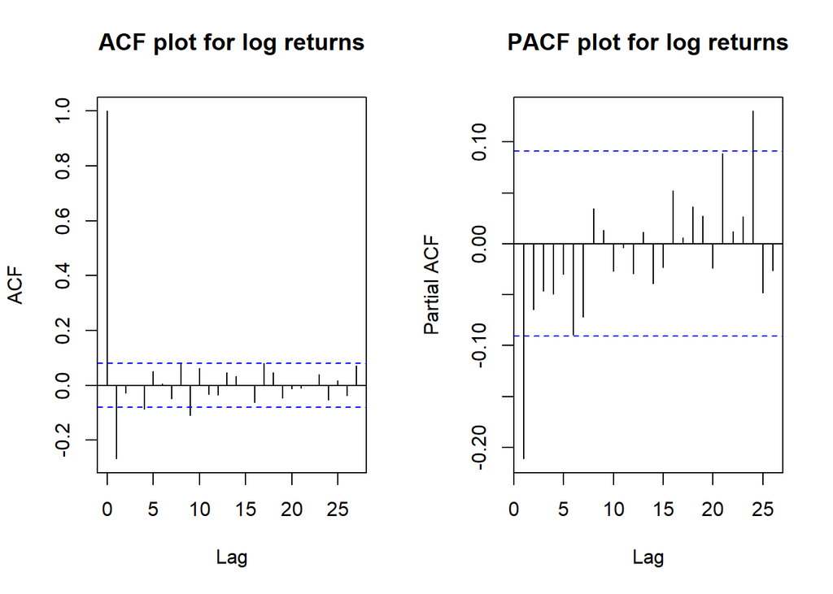

```r
par(mfrow = c(1, 2))
acf(log_r1[[1]]$log_return, main = "ACF plot for log returns")
pacf(log_r, main = "PACF plot for log returns")
```

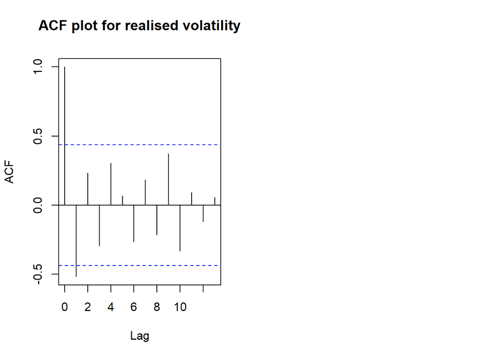

```r
acf(vol[[1]]$volatility, main = "ACF plot for realised volatility")
```

Looking at the ACF plot for realised volatility, amongst the lags, only lag 1 is above the confidence bands (negative correlations). This indicates there is a statistically significant correlation between the current volatility and the previous volatility. Also, since there is only one lag above the confidence bands, this indicates that the time series has short-term memory (Peiris & Hunt, 2023). This means the current volatility is mainly affected by the most recent time period. This could also suggest older data might contribute little to no predictions. It is suggested that a simple model could be built to focus on the immediate past values. Hence, models that mainly capture short-term autocorrelation such as Heterogeneous AutoRegressive (HAR) could be used. This is because more complex models such as ARMA-GARCH may not be necessary for adding valuable information in predicting volatility with this data.

## Data Split: Training & Validation

Before building the models, the data is split into training and validation sets. The data is split into a training set with the first 16 buckets and the rest for the validation set. This approach is used because the dataset includes order book snapshots that are taken every second over many 10-minute intervals. With the aggregation of 30-second intervals we did to simplify the big data. This results in 20 intervals (buckets) for each 10-minute interval.

For the training data, the first 8 minutes or 480 seconds of each 10-minute interval are used. This explains the 16 buckets in the code. While the validation data uses the last 2 minutes or 120 seconds, that gives us 4 buckets. With this approach, the method of 80:20 split is used for each 10-minute interval. This approach allows 80% of data to be used for training, while 20% is used for validation. This also allows the models to learn from historical data but still use new data to evaluate the performances. Then, the following sections explain each of the models built.

```r
vol.train <- list()
vol.val <- list()

for (i in 1 : length(log_r1)) {
  vol.train[[i]] <- vol[[i]][1:16, ]
  vol.val[[i]] <- vol[[i]][-(1:16), ]
}
```

## Candidate Models

### I. Linear Regression

A linear regression model is built to predict volatility with three main statistics, price, order volume and BidAskPrice. They are used to measuring for each 30-second interval to analyse the short-term market changes. We took an approach of giving more weight to recent data points. This is aimed at improving the model’s accuracy and help the model to adjust more effectively to changing market conditions. The model is then developed separately for different time intervals using historical volatility data. The model also assesses how changes in the three statistics affect the future volatility. This model, however, assumes the inputs and volatility are directly related. This could cause the model to not closely align with complex financial data. But still, this model is simple and straightforward, and useful for understanding the key factors that affect volatility.

```r
list.reg <- list()
stock1 <- stock1 %>% mutate(time_bucket = ceiling(seconds_in_bucket / 30),
                            num_order = bid_size1 + ask_size1 + bid_size2 + ask_size2)
len.train <- length(vol.train[[1]]$volatility)

for (i in 1 : length(vol)) {
  stats.bucket <- stock1 %>%
    filter(time_id == time_IDs[i] & time_bucket != 0) %>%
    select(c(BidAskSpread, WAP, num_order, time_bucket))
  # cal stats for each 30-sec time bucket
  mean.price <- aggregate(WAP ~ time_bucket, data = stats.bucket, FUN = mean)
  mean.order <- aggregate(num_order ~ time_bucket, data = stats.bucket, FUN = mean)
  mean.BAS <- aggregate(BidAskSpread ~ time_bucket, data = stats.bucket, FUN = mean)
  list.reg[[i]] <- data.frame(volatility = vol.train[[i]]$volatility[-1],
                              price = mean.price$WAP[1:(len.train - 1)],
                              order = mean.order$num_order[1:(len.train - 1)],
                              BidAskSpread = mean.BAS$BidAskSpread[1:(len.train - 1)])
}

lm.models <- list()

for (i in 1 : length(vol)) {
  lm.models[[i]] <- lm(volatility ~ price + order + BidAskSpread, list.reg[[i]],
                       weights = 0.8 ^ (((len.train - 2):0) / 2))
}
summary(lm.models[[162]])
```

```
Call:
lm(formula = volatility ~ price + order + BidAskSpread, data = list.reg[[i]],
    weights = 0.8^(((len.train - 2):0)/2))

Weighted Residuals:
       Min         1Q     Median         3Q        Max
-2.608e-04 -5.448e-05  3.796e-05  6.759e-05  1.985e-04

Coefficients:
               Estimate Std. Error t value Pr(>|t|)
(Intercept)  -4.557e-01  1.274e-01  -3.578  0.00433 **
price         4.559e-01  1.271e-01   3.588  0.00426 **
order        -1.334e-07  6.337e-07  -0.211  0.83711
BidAskSpread -1.277e-01  4.033e-01  -0.317  0.75752
---
Signif. codes:  0 '***' 0.001 '**' 0.01 '*' 0.05 '.' 0.1 ' ' 1

Residual standard error: 0.0001356 on 11 degrees of freedom
Multiple R-squared:  0.7411,    Adjusted R-squared:  0.6704
F-statistic: 10.49 on 3 and 11 DF,  p-value: 0.001477
```

**Comparing Actual and Predicted Volatility (Out-of-Sample)**

After fitting the model, we assess the performance by comparing the actual and predicted volatility. Here, we use the out-of-sample validation method that uses the last four time intervals (which is the validation set). This method is to evaluate how well the model predicts future volatility and generalises while preventing overfitting.

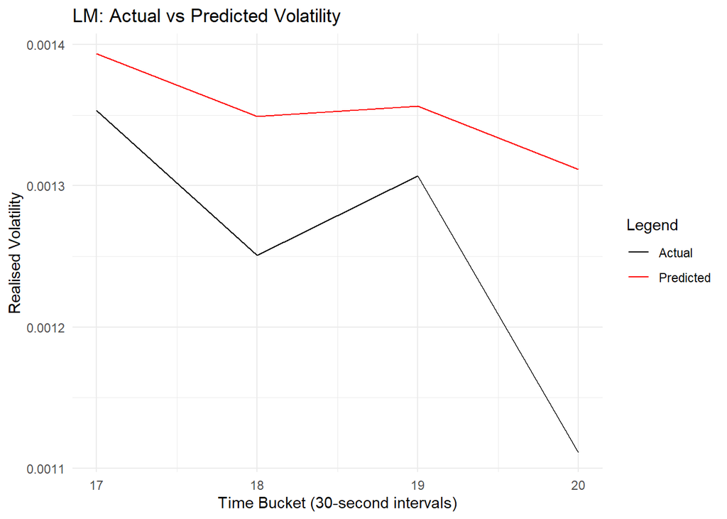

```r
list.reg.val <- list()
len.val <- length(vol.val[[1]]$volatility)
pred.lm <- list()

for (i in 1 : length(vol)) {
  stats.bucket <- stock1 %>%
    filter(time_id == time_IDs[i] & time_bucket != 0) %>%
    select(c(BidAskSpread, WAP, num_order, time_bucket))
  mean.price <- aggregate(WAP ~ time_bucket, data = stats.bucket, FUN = mean)
  mean.order <- aggregate(num_order ~ time_bucket, data = stats.bucket, FUN = mean)
  mean.BAS <- aggregate(BidAskSpread ~ time_bucket, data = stats.bucket, FUN = mean)
  list.reg.val[[i]] <-
    data.frame(volatility = vol.val[[i]]$volatility,
               price = mean.price$WAP[len.train:(len.train + len.val - 1)],
               order = mean.order$num_order[len.train:(len.train + len.val - 1)],
               BidAskSpread = mean.BAS$BidAskSpread[len.train:(len.train + len.val - 1)])
  pred.lm[[i]] <- predict(lm.models[[i]], newdata = list.reg.val[[i]])
}

lm_val_predictions <- predict(lm.models[[1]], newdata = list.reg.val[[1]])

# out‑of‑sample validation
# showing the last 4 time intervals -- THE validation set

df_lm <- data.frame(
  time_bucket = vol.val[[1]]$time_bucket,
  Actual = vol.val[[1]]$volatility,
  Predicted = lm_val_predictions
)

ggplot(df_lm, aes(x = time_bucket)) +
  geom_line(aes(y = Actual, color = "Actual")) +
  geom_line(aes(y = Predicted, color = "Predicted")) +
  labs(title = "LM: Actual vs Predicted Volatility",
       x = "Time Bucket (30-second intervals)",
       y = "Realised Volatility") +
  scale_color_manual(name = "Legend", values = c("Actual" = "black", "Predicted" = "red")) +
  theme_minimal()
```

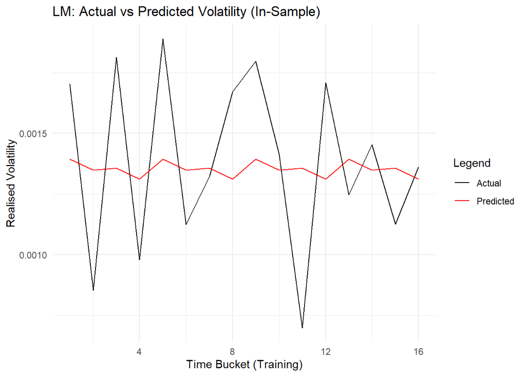

```r
df_lm_in <- data.frame(
  time_bucket = vol.train[[1]]$time_bucket,  # e.g., 1, 2, ..., 16
  Actual = vol.train[[1]]$volatility,
  Predicted = lm_val_predictions
)
ggplot(df_lm_in, aes(x = time_bucket)) +
  geom_line(aes(y = Actual, color = "Actual")) +
  geom_line(aes(y = Predicted, color = "Predicted")) +
  labs(title = "LM: Actual vs Predicted Volatility (In-Sample)",
       x = "Time Bucket (Training)",
       y = "Realised Volatility") +
  scale_color_manual(name = "Legend", values = c("Actual" = "black", "Predicted" = "red")) +
  theme_minimal()
```

### II. HAR

#### i. Fitting HAR Model with Validation Set

```r
# the default dataset with complete data
har_data_common <- vol[[1]] %>%
  mutate(
    vol_lag1  = lag(volatility, n = 1),
    vol_last3 = rollmean(volatility, k = 3, fill = NA, align = "right"),
    vol_last5 = rollmean(volatility, k = 5, fill = NA, align = "right")
  ) %>%
  filter(!is.na(vol_lag1) & !is.na(vol_last3) & !is.na(vol_last5))

n_total <- nrow(har_data_common)
# split into 80% for training, 20% for validation
n_train <- floor(0.8 * n_total)
har_train <- har_data_common[1:n_train, ]
har_val   <- har_data_common[(n_train + 1):n_total, ]

# for validation set only -- out-of-sample
har_model_val <- lm(volatility ~ vol_lag1 + vol_last3 + vol_last5, data = har_train)
summary(har_model_val)
```

```
Call:
lm(formula = volatility ~ vol_lag1 + vol_last3 + vol_last5, data = har_train)

Residuals:
       Min         1Q     Median         3Q        Max
-5.733e-04 -5.323e-05  6.962e-05  1.171e-04  2.773e-04

Coefficients:
             Estimate Std. Error t value Pr(>|t|)
(Intercept) -0.001185   0.001425  -0.832    0.430
vol_lag1    -0.384053   0.231082  -1.662    0.135
vol_last3    0.937516   0.736388   1.273    0.239
vol_last5    1.288705   1.224333   1.053    0.323

Residual standard error: 0.0002663 on 8 degrees of freedom
Multiple R-squared:  0.5432,    Adjusted R-squared:  0.372
F-statistic: 3.172 on 3 and 8 DF,  p-value: 0.08519
```

From the output, we can learn that the predictors do not show strong statistical significance. The model test is also not statistically significant with a p-value of 0.0852. These suggested that the model does not capture the relationship between the immediate previous bucket and volatility effectively. Hence, further analysis is needed.

**Comparing Actual and Predicted Volatility (Out-of-Sample)**

Again, the performance of the model predicting volatility using the out-of-sample method is visualised.

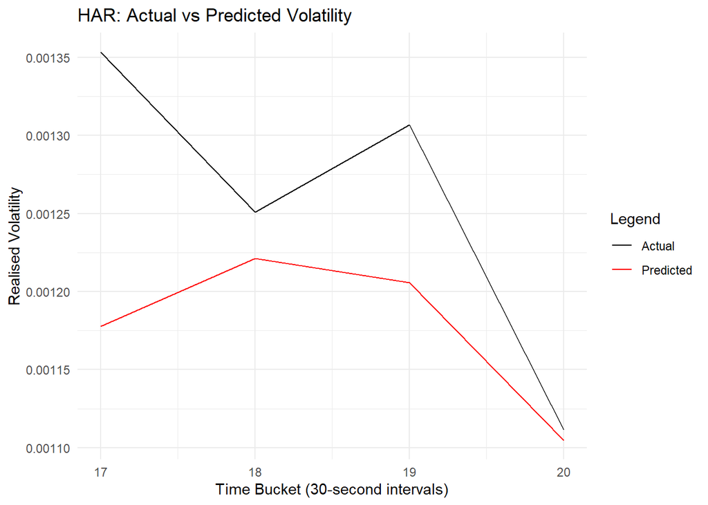

```r
har_val <- har_val %>%
  mutate(predicted_vol = predict(har_model_val, newdata = har_val))

ggplot(har_val, aes(x = time_bucket)) +
  geom_line(aes(y = volatility, color = "Actual"), na.rm = TRUE) +
  geom_line(aes(y = predicted_vol, color = "Predicted"), na.rm = TRUE) +
  labs(title = "HAR: Actual vs Predicted Volatility",
       x = "Time Bucket (30-second intervals)",
       y = "Realised Volatility") +
  scale_color_manual(name = "Legend", values = c("Actual" = "black", "Predicted" = "red")) +
  theme_minimal()
```

The plot suggests the HAR model using the validation set is not highly accurate. This is because the predicted volatility does not closely align with the actual volatility. When it comes to higher time intervals (time bucket 19), the model is not able to capture the sudden spike. This shows the limitation of the modelling approach as it does not accurately reflect the short-term changes. However, the general trend is still being able to be identified by the model. The model manages to reflect the overall patterns in changes in volatility, showing a decrease in volatility over time. This indicates the model shows some reliability in predicting broader volatility trends, even though it is not highly accurate. Hence, we explore another method to fit the HAR model.

#### ii. Fitting HAR Model with Full Set

Here, we are interested in exploring the overall accuracy of the HAR model with both training and testing data. Instead of using the split data, we use the full data and perform an in-sample validation. Here, instead of using the validation data, we use the full data.

```r
# for full dataset -- in-sample
har_model_full <- lm(volatility ~ vol_lag1 + vol_last3 + vol_last5, data = har_data_common)
summary(har_model_full)
```

```
Call:
lm(formula = volatility ~ vol_lag1 + vol_last3 + vol_last5, data = har_data_common)

Residuals:
       Min         1Q     Median         3Q        Max
-5.908e-04 -3.743e-05  3.682e-05  1.215e-04  2.628e-04

Coefficients:
              Estimate Std. Error t value Pr(>|t|)
(Intercept) -0.0008656  0.0009753  -0.888   0.3922
vol_lag1    -0.3924608  0.1918926  -2.045   0.0634 .
vol_last3    0.9345597  0.6075022   1.538   0.1499
vol_last5    1.0811211  0.9238122   1.170   0.2646
---
Signif. codes:  0 '***' 0.001 '**' 0.01 '*' 0.05 '.' 0.1 ' ' 1

Residual standard error: 0.0002233 on 12 degrees of freedom
Multiple R-squared:  0.5529,    Adjusted R-squared:  0.4412
F-statistic: 4.947 on 3 and 12 DF,  p-value: 0.01837
```

**Comparing Actual and Predicted Volatility (In-Sample)**

The comparison plot to visualise both actual and predicted volatility is created.

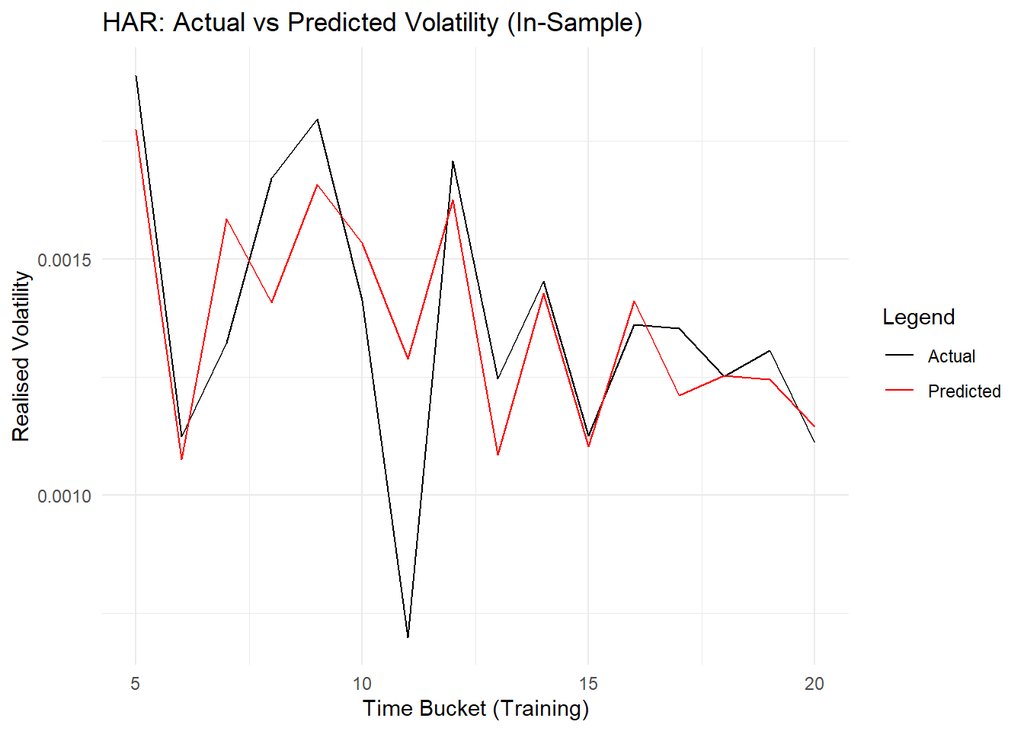

```r
har_data_common <- har_data_common %>%
  mutate(fitted_vol = har_model_full$fitted.values)

ggplot(har_data_common, aes(x = time_bucket)) +
  geom_line(aes(y = volatility, color = "Actual"), na.rm = TRUE) +
  geom_line(aes(y = fitted_vol, color = "Predicted"), na.rm = TRUE) +
  labs(title = "HAR: Actual vs Predicted Volatility (In-Sample)",
       x = "Time Bucket (Training)",
       y = "Realised Volatility") +
  scale_color_manual(name = "Legend", values = c("Actual" = "black", "Predicted" = "red")) +
  theme_minimal()
```

The HAR model that uses the full set data now shows better alignments between the actual and predicted volatility. We can see both predicted and actual volatilities are closely aligned, especially between time buckets 12 to 16. This suggests using the in-sample method, including the immediate lag predictor, is useful to capture the short-term trends in data more accurately.

### III. HAV-RV

```r
list.HAV <- list()

for (i in 1 : length(vol)) {
  mean.vol <- rep(0, len.train - 5)
  for (j in 1 : 5) {
    mean.vol <- mean.vol + vol.train[[i]]$volatility[j : (j + len.train - 6)] / 5
  }
  list.HAV[[i]] <- data.frame(vol = vol.train[[i]]$volatility[-(1:5)],
                              vol_1 = vol.train[[i]]$volatility[5:(len.train - 1)],
                              mean_vol_5 = mean.vol)
}

quar <- list()
comp_quar <- function(x) {
  return(length(x) / 3 * sum(x ^ 4))
}
for (i in 1 : length(log_r1)) {
  quar[[i]] <- aggregate(log_return ~ time_bucket, data = log_r1[[i]], FUN = comp_quar)
  colnames(quar[[i]]) <- c('time_bucket', 'quarticity')
}

HAV.ols.models <- list()
HAV.wls.models <- list()

for (i in 1 : length(vol)) {
  HAV.ols.models[[i]] <- lm(vol ~ vol_1 + mean_vol_5, list.HAV[[i]])

  HAV.wls.models[[i]] <- lm(vol ~ vol_1 + mean_vol_5, list.HAV[[i]],
                            weights = list.HAV[[i]]$vol_1 /
                              sqrt(quar[[i]]$quarticity[5:(len.train - 1)]))
}
summary(HAV.wls.models[[162]])
```

```
Call:
lm(formula = vol ~ vol_1 + mean_vol_5, data = list.HAV[[i]],
    weights = list.HAV[[i]]$vol_1/sqrt(quar[[i]]$quarticity[5:(len.train -
        1)]))

Weighted Residuals:
       Min         1Q     Median         3Q        Max
-0.0126058 -0.0019508  0.0003314  0.0034987  0.0073037

Coefficients:
              Estimate Std. Error t value Pr(>|t|)
(Intercept) -0.0001962  0.0002708  -0.725    0.489
vol_1        0.5066338  0.2821824   1.795    0.110
mean_vol_5   0.6298181  0.5859442   1.075    0.314

Residual standard error: 0.006683 on 8 degrees of freedom
Multiple R-squared:  0.752, Adjusted R-squared:  0.6901
F-statistic: 12.13 on 2 and 8 DF,  p-value: 0.00378
```

Using the in-sample validation, we can see the performance of the HAV model is better than LM and HAR, with 75% of R². However, this is only showing how well the model fits with the training data. We will look more closely with how the model performs when used in predicting future volatility.

**Comparing Actual and Predicted Volatility (Out-of-Sample)**

```r
list.HAV.val <- list()

for(i in 1:length(vol)) {
  len_val <- nrow(vol.val[[i]])
  seed <- tail(vol.train[[i]]$volatility, 5)
  val_vol <- vol.val[[i]]$volatility
  combined <- c(seed, val_vol)

  n_comb <- length(combined)
  mean_vol <- rep(0, n_comb - 5)
  for (j in 1:5) {
    mean_vol <- mean_vol + combined[j:(j + n_comb - 6)] / 5
  }

  HAV_val_df <- data.frame(
    vol = tail(combined[-(1:5)], len_val),
    vol_1 = tail(combined[5:n_comb], len_val),
    mean_vol_5 = tail(mean_vol, len_val)
  )
  list.HAV.val[[i]] <- HAV_val_df
}

summary(HAV.wls.models[[162]])
```

```
Call:
lm(formula = vol ~ vol_1 + mean_vol_5, data = list.HAV[[i]],
    weights = list.HAV[[i]]$vol_1/sqrt(quar[[i]]$quarticity[5:(len.train -
        1)]))

Weighted Residuals:
       Min         1Q     Median         3Q        Max
-0.0126058 -0.0019508  0.0003314  0.0034987  0.0073037

Coefficients:
              Estimate Std. Error t value Pr(>|t|)
(Intercept) -0.0001962  0.0002708  -0.725    0.489
vol_1        0.5066338  0.2821824   1.795    0.110
mean_vol_5   0.6298181  0.5859442   1.075    0.314

Residual standard error: 0.006683 on 8 degrees of freedom
Multiple R-squared:  0.752, Adjusted R-squared:  0.6901
F-statistic: 12.13 on 2 and 8 DF,  p-value: 0.00378
```

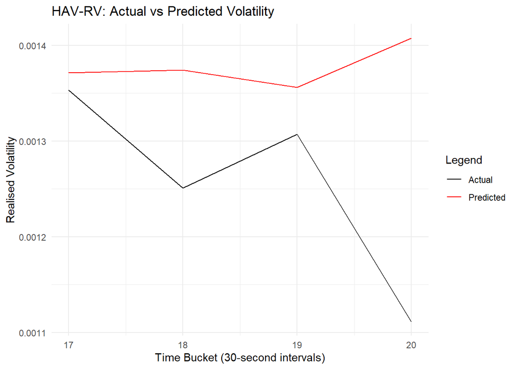

```r
hav_predictions_val <- predict(HAV.wls.models[[1]], newdata = list.HAV.val[[1]])

df_hav <- data.frame(
  time_bucket = vol.val[[1]]$time_bucket,
  Actual = list.HAV.val[[1]]$vol,
  Predicted = hav_predictions_val
)

ggplot(df_hav, aes(x = time_bucket)) +
  geom_line(aes(y = Actual, color = "Actual")) +
  geom_line(aes(y = Predicted, color = "Predicted")) +
  labs(title = "HAV-RV: Actual vs Predicted Volatility",
       x = "Time Bucket (30-second intervals)",
       y = "Realised Volatility") +
  scale_color_manual(name = "Legend", values = c("Actual" = "black", "Predicted" = "red")) +
  theme_minimal()
```

**Comparing Actual and Predicted Volatility (In-Sample)**

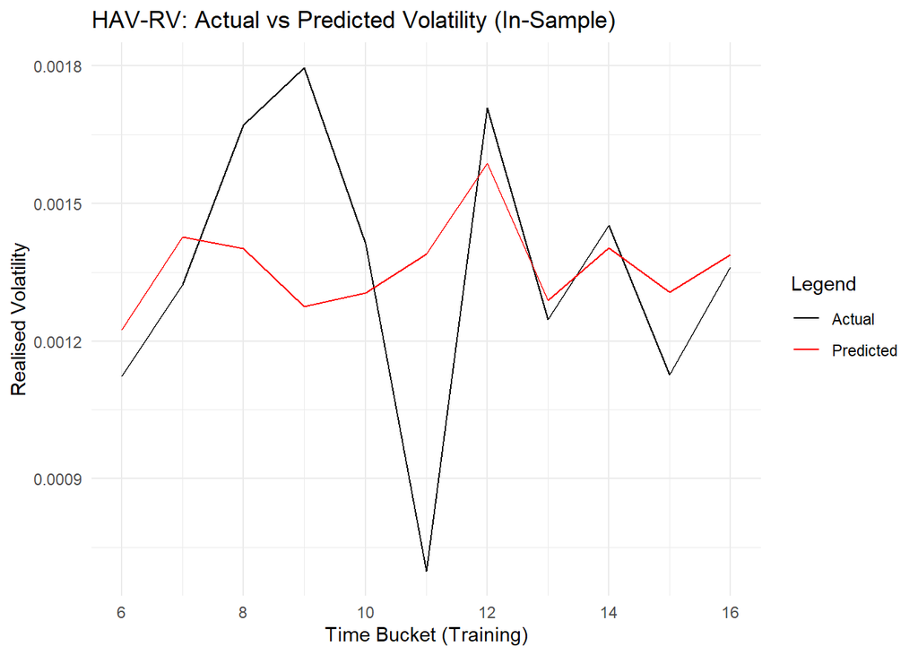

```r
harv_in_predictions <- predict(HAV.wls.models[[1]], newdata = list.HAV[[1]])

df_hav_in <- data.frame(
  time_bucket = vol.train[[1]]$time_bucket[-(1:5)],  # drop first 5 buckets
  Actual = list.HAV[[1]]$vol,
  Predicted = harv_in_predictions
)

ggplot(df_hav_in, aes(x = time_bucket)) +
  geom_line(aes(y = Actual, color = "Actual")) +
  geom_line(aes(y = Predicted, color = "Predicted")) +
  labs(title = "HAV-RV: Actual vs Predicted Volatility (In-Sample)",
       x = "Time Bucket (Training)",
       y = "Realised Volatility") +
  scale_color_manual(name = "Legend", values = c("Actual" = "black", "Predicted" = "red")) +
  theme_minimal()
```

### IV. GARCH

A GARCH model is built to analyse changes in volatility over time, assuming volatility to follow a pattern of past variations. This model is useful for observing how markets change over time by identifying trends in historical volatility. Moreover, it is able to capture volatility clustering effectively, and to identify periods of significant and minimal market changes. It is also a more flexible approach to predicting future volatility using historical patterns.

To define the model, we use `GARCH(1,1)` model, which means today’s volatility is affected by both past volatility and shocks. Then, we fit the model using different time intervals, with data from the first 8 minutes to predict volatility. The model then predicts future volatility for the next 30-second intervals. The average predicted volatility during this time period is also calculated. Then, the actual and predicted volatility are used to compare to give us insights about the ability of the model to reflect real market changes.

```r
garch_spec <- ugarchspec(
  variance.model = list(model = "sGARCH", garchOrder = c(1, 1)),
  mean.model = list(armaOrder = c(0, 0), include.mean = TRUE),
  distribution.model = "norm"
)

# fit GARCH model for each segment in volatility
GARCH.models <- list()
for (i in 1:length(vol)) {
  GARCH.models[[i]] <- ugarchfit(
    spec = garch_spec,
    data = log_r1[[i]] %>% filter(time <= 480) %>% pull(log_return),
    solver = 'hybrid'
  )
}

GARCH.pred <- rep(NA, length(vol))
for (i in 1:length(vol)) {
  # predict ahead 30 steps
  # ugarchforecast func output predict obj
  fc <- ugarchforecast(GARCH.models[[i]], n.ahead = 30)

  # extract predict sigma -- volatiltity
  sigma_forecast <- sigma(fc)

  # calculate mean predict volatility
  GARCH.pred[i] <- mean(sigma_forecast)
}
```

**Comparing Actual and Predicted Volatility (Out-of-Sample)**

Similarly, we visualise the comparison between the actual and predicted volatility.

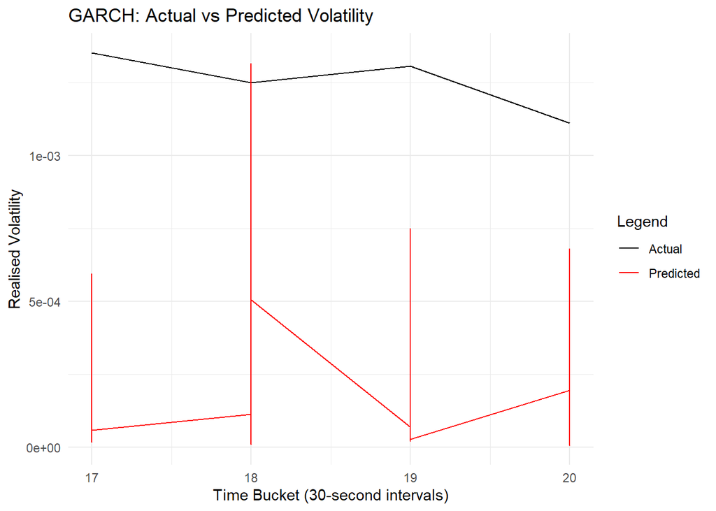

```r
df_garch <- data.frame(
  time_bucket = vol.val[[1]]$time_bucket,
  Actual = vol.val[[1]]$volatility,
  Predicted = GARCH.pred
)

ggplot(df_garch, aes(x = time_bucket)) +
  geom_line(aes(y = Actual, color = "Actual")) +
  geom_line(aes(y = Predicted, color = "Predicted")) +
  labs(title = "GARCH: Actual vs Predicted Volatility",
       x = "Time Bucket (30-second intervals)",
       y = "Realised Volatility") +
  scale_color_manual(name = "Legend", values = c("Actual" = "black", "Predicted" = "red")) +
  theme_minimal()
```

Using the same out-of-sample validation approach, the plot suggests the predicted volatility shows an obvious change even though the actual data are flat. This indicates the GARCH model is not aligning with the predicted volatility closely. We can see that the predictions fluctuate more even though the actual volatility remains stable in the last four time intervals. Hence, it could be suggested that the GARCH model is less accurate in this out-of-sample period to capture the volatility trend.

**Comparing Actual and Predicted Volatility (In-Sample)**

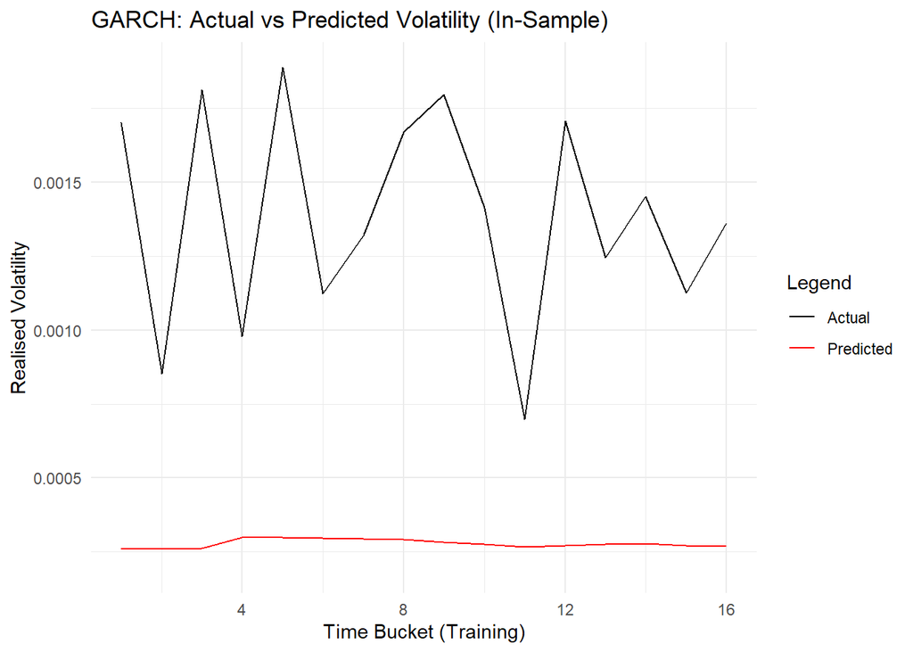

```r
garch_in_sigma <- sigma(GARCH.models[[1]])
n_in <- length(garch_in_sigma)

df_garch_in <- data.frame(
  time_bucket = vol.train[[1]]$time_bucket[1:n_in],
  Actual      = vol.train[[1]]$volatility[1:n_in],
  Predicted   = garch_in_sigma
)

ggplot(df_garch_in, aes(x = time_bucket)) +
  geom_line(aes(y = Actual, color = "Actual")) +
  geom_line(aes(y = Predicted, color = "Predicted")) +
  labs(title = "GARCH: Actual vs Predicted Volatility (In-Sample)",
       x = "Time Bucket (Training)",
       y = "Realised Volatility") +
  scale_color_manual(name = "Legend", values = c("Actual" = "black", "Predicted" = "red")) +
  theme_minimal()
```

## Evaluation Metrics

```r
evaluate_model <- function(actual, predicted) {
  rmse <- sqrt(mean((actual - predicted)^2))
  mae  <- mean(abs(actual - predicted))
  r2   <- 1 - sum((actual - predicted)^2) / sum((actual - mean(actual))^2)
  mape <- mean(abs((actual - predicted) / actual)) * 100
  return(list(RMSE = rmse, MAE = mae, R2 = r2, MAPE = mape))
}

# LM
lm_predictions <- predict(lm.models[[1]], newdata = list.reg.val[[1]])
lm_eval <- evaluate_model(vol.val[[1]]$volatility, lm_predictions)

# HAR
har_predictions <- predict(har_model_val, newdata = har_val)
har_eval <- evaluate_model(har_val$volatility, har_predictions)

har_common_predictions <- predict(har_model_full, newdata = har_data_common)
har_common_eval <- evaluate_model(har_data_common$volatility, har_common_predictions)

# GARCH -- using validation set from vol.val[[1]]
garch_eval <- evaluate_model(vol.val[[1]]$volatility, GARCH.pred)

# HAV
hav_predictions <- predict(HAV.wls.models[[1]], newdata = list.HAV[[1]])
hav_eval <- evaluate_model(list.HAV[[1]]$vol, hav_predictions_val)

# compare
models_eval <- data.frame(
  Model = c("Linear Regression", "HAR (Out-of-Sample)", "HAR (In-Sample)", "HAV-RV", "GARCH"),
  RMSE  = c(lm_eval$RMSE, har_eval$RMSE, har_common_eval$RMSE, hav_eval$RMSE, garch_eval$RMSE),
  MAE   = c(lm_eval$MAE, har_eval$MAE, har_common_eval$MAE, hav_eval$RMSE, garch_eval$MAE),
  R2    = c(lm_eval$R2, har_eval$R2, har_common_eval$R2, hav_eval$RMSE, garch_eval$R2),
  MAPE  = c(lm_eval$MAPE, har_eval$MAPE, har_common_eval$MAPE, hav_eval$RMSE, garch_eval$MAPE)
)

print(models_eval)
```

```
                Model         RMSE          MAE            R2         MAPE
1   Linear Regression 0.0001159333 9.698394e-05 -6.260352e-01 8.152757e+00
2 HAR (Out-of-Sample) 0.0001024392 7.819077e-05 -2.695374e-01 5.914434e+00
3     HAR (In-Sample) 0.0001933930 1.326104e-04  5.529320e-01 1.190716e+01
4              HAV-RV 0.0003000382 3.000382e-04  3.000382e-04 3.000382e-04
5               GARCH 0.0010797557 1.067630e-03 -1.762989e+04 8.503064e+01
```

**Model Selection and Final Justification**

In this evaluation analysis, the HAR (Out-of-Sample) model shows the strongest predictive ability with high-frequency data. One limitation here is that this model shows a negative R² value, indicating difficulty in achieving strong explanatory power. Despite showing negative R² values, this is common in financial data because of the unpredictable volatile nature. With the other metrics such as RMSE, MAE and MAPE, these give us a better understanding of the models’ accuracy. Moreover, the HAR (Out-of-Sample) model used the lagged volatility and rolling averages effectively. This makes it more stable and reliable. Comparing it with linear regression and GARCH models, the HAR (Out-of-Sample) model is a better option.

It is also understandable that the HAR (Out-of-Sample) model performs better than the other models because it is often used to model time-dependent features. This actually aligns with our data characteristics, while models like GARCH are more suitable to capture volatility clustering. With high-frequency data, small mis-specifications or noise can cause the model to be unstable and make the model over sensitive in predictions. Overall, although no model predicted volatility with 100% accuracy, the HAR model shows a good balance between precision and usability for high-frequency data.

## Additional Exploration

### Bucket Size Adjustment

This is an extra part that explore the performances of the same models used (LM, HAR, and GARCH) but with **an adjustment of the bucket size**. Initially, we used a bucket size of 30-second intervals, but here we use a bucket size of 60. This is aimed to reduce noise that is relative to the 30-second intervals. However, the result of the performance metrics are not ideal. In fact, the 30-second bucket approach is performing better for our predictive task with high-frequency data.

We can learn that the 30-second bucket approach has better predictive performance. This is supported by lower RMSE and MAPE, showing the predicted volatility is closer to the actual volatility. Moreover, this approach allows more data points to be used in predicting future volatility with more detailed view of volatility changes. This can be useful for making trading decisions more accurately as increasing the bucket size can sometimes reduce noise. On the other hand, increasing bucket size approach resulted in fewer data points instead and worsen the out-of-sample performance.

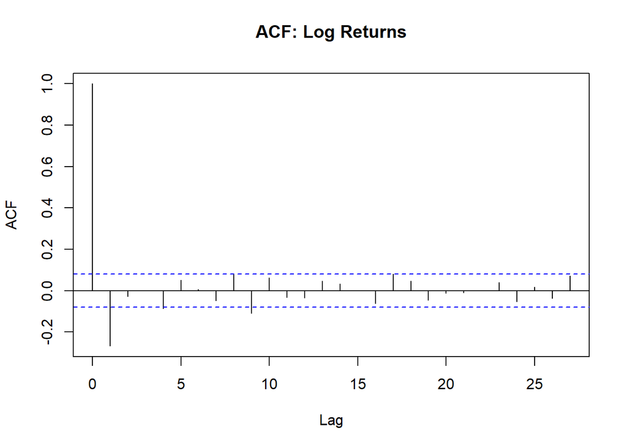

```r
stock1 <- read.csv("stock_1.csv")

# data processing
stock1 <- stock1 %>%
  mutate(WAP = (bid_price1 * ask_size1 + ask_price1 * bid_size1) / (bid_size1 + ask_size1),
         BidAskSpread = ask_price1 / bid_price1 - 1)

# use subset -- first 500 time_ids
time_IDs <- unique(stock1$time_id)[1:500]

# realized volatility from log returns
comp_vol <- function(x) {
  sqrt(sum(x^2))
}

bucket_size <- 60
log_r1 <- list()
vol <- list()

for(i in 1:length(time_IDs)) {
  tmp <- stock1 %>% filter(time_id == time_IDs[i])
  sec <- tmp$seconds_in_bucket
  price <- tmp$WAP

  # log returns from past prices
  if(length(price) >= 2) {
    log_r <- log(price[-1] / price[-length(price)])
  } else {
    log_r <- NA
  }

  # assign log returns to corresponding time stamps
  df_lr <- data.frame(time = sec[-1], log_return = log_r)
  # replace 0 for log return for missing seconds
  time_seq <- seq(1, max(sec))
  missing_times <- setdiff(time_seq, df_lr$time)
  if(length(missing_times) > 0) {
    df_missing <- data.frame(time = missing_times, log_return = 0)
    df_lr <- rbind(df_lr, df_missing)
    df_lr <- df_lr[order(df_lr$time), ]
  }
  log_r1[[i]] <- df_lr

  # non-overlapping buckets using bucket_size
  df_lr <- df_lr %>% mutate(time_bucket = ceiling(time / bucket_size))

  # agg log returns for realized volatility in each bucket
  vol[[i]] <- aggregate(log_return ~ time_bucket, data = df_lr, FUN = comp_vol)
  colnames(vol[[i]]) <- c("time_bucket", "volatility")
}

## EDA -- check autocorrelation (time_ID 1)
acf(log_r1[[1]]$log_return, main = "ACF: Log Returns")
```

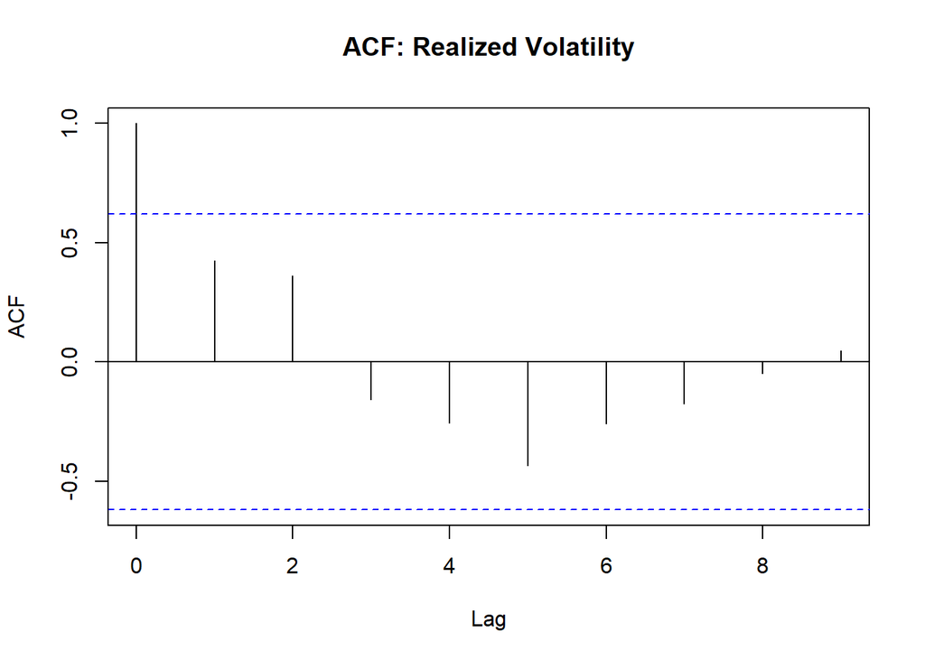

```r
acf(vol[[1]]$volatility, main = "ACF: Realized Volatility")
```

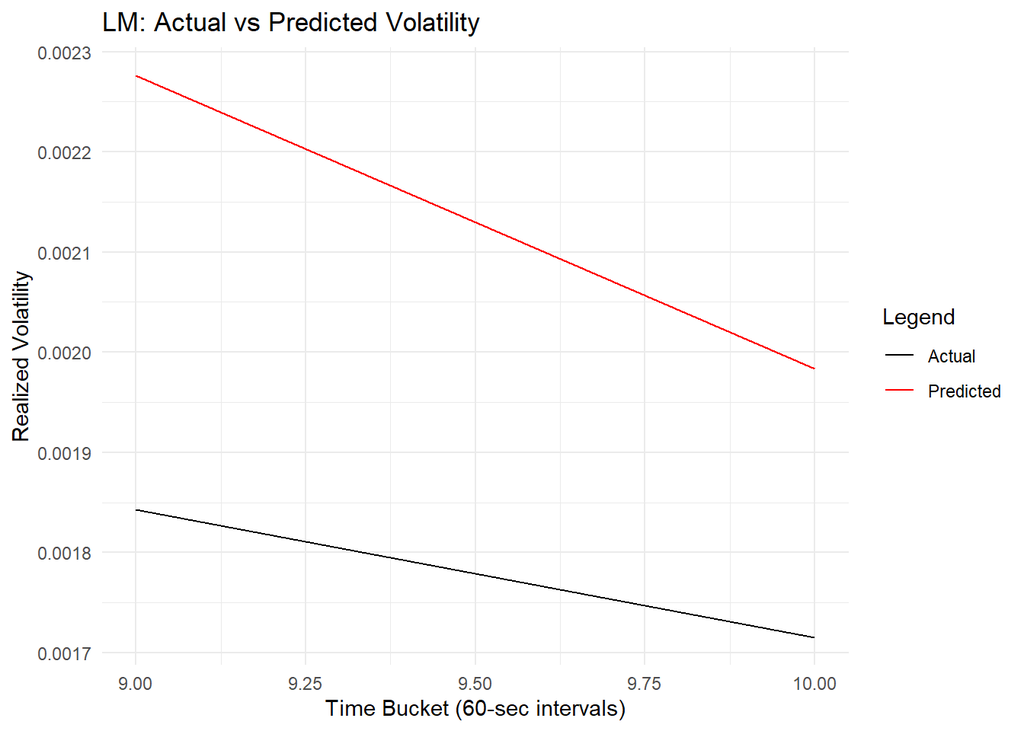

```r
## training & testing
vol.train <- list()
vol.val <- list()

# 80:20 split
for(i in 1:length(vol)) {
  total_buckets <- nrow(vol[[i]])
  n_train <- floor(0.8 * total_buckets)
  vol.train[[i]] <- vol[[i]][1:n_train, ]
  vol.val[[i]] <- vol[[i]][(n_train + 1):total_buckets, ]
}

# LM
stock1 <- stock1 %>%
  mutate(time_bucket = ceiling(seconds_in_bucket / bucket_size),
         num_order = bid_size1 + ask_size1 + bid_size2 + ask_size2)

list.reg <- list()
len.train <- nrow(vol.train[[1]])
for(i in 1:length(vol)) {
  stats.bucket <- stock1 %>% filter(time_id == time_IDs[i] & time_bucket != 0) %>%
                   select(BidAskSpread, WAP, num_order, time_bucket)
  mean.price <- aggregate(WAP ~ time_bucket, data = stats.bucket, FUN = mean)
  mean.order <- aggregate(num_order ~ time_bucket, data = stats.bucket, FUN = mean)
  mean.BAS <- aggregate(BidAskSpread ~ time_bucket, data = stats.bucket, FUN = mean)

  list.reg[[i]] <- data.frame(
    volatility = vol.train[[i]]$volatility[-1],
    price = mean.price$WAP[1:(len.train - 1)],
    order = mean.order$num_order[1:(len.train - 1)],
    BidAskSpread = mean.BAS$BidAskSpread[1:(len.train - 1)]
  )
}

# fit LM for each time_id
lm.models <- list()
for(i in 1:length(vol)) {
  lm.models[[i]] <- lm(volatility ~ price + order + BidAskSpread, data = list.reg[[i]],
                       weights = 0.8 ^ (((len.train - 2):0) / 2))
}

# validation set for LM
len.val <- nrow(vol.val[[1]])
list.reg.val <- list()
pred.lm <- list()
for(i in 1:length(vol)) {
  stats.bucket <- stock1 %>% filter(time_id == time_IDs[i] & time_bucket != 0) %>%
                   select(BidAskSpread, WAP, num_order, time_bucket)
  mean.price <- aggregate(WAP ~ time_bucket, data = stats.bucket, FUN = mean)
  mean.order <- aggregate(num_order ~ time_bucket, data = stats.bucket, FUN = mean)
  mean.BAS <- aggregate(BidAskSpread ~ time_bucket, data = stats.bucket, FUN = mean)

  list.reg.val[[i]] <- data.frame(
    volatility = vol.val[[i]]$volatility,
    price = mean.price$WAP[len.train:(len.train + nrow(vol.val[[i]]) - 1)],
    order = mean.order$num_order[len.train:(len.train + nrow(vol.val[[i]]) - 1)],
    BidAskSpread = mean.BAS$BidAskSpread[len.train:(len.train + nrow(vol.val[[i]]) - 1)]
  )
  pred.lm[[i]] <- predict(lm.models[[i]], newdata = list.reg.val[[i]])
}

# compare plot
lm_val_predictions <- pred.lm[[1]]
df_lm <- data.frame(
  time_bucket = vol.val[[1]]$time_bucket,
  Actual = vol.val[[1]]$volatility,
  Predicted = lm_val_predictions
)
ggplot(df_lm, aes(x = time_bucket)) +
  geom_line(aes(y = Actual, color = "Actual")) +
  geom_line(aes(y = Predicted, color = "Predicted")) +
  labs(title = "LM: Actual vs Predicted Volatility",
       x = "Time Bucket (60-sec intervals)",
       y = "Realized Volatility") +
  scale_color_manual(name = "Legend", values = c("Actual" = "black", "Predicted" = "red")) +
  theme_minimal()
```

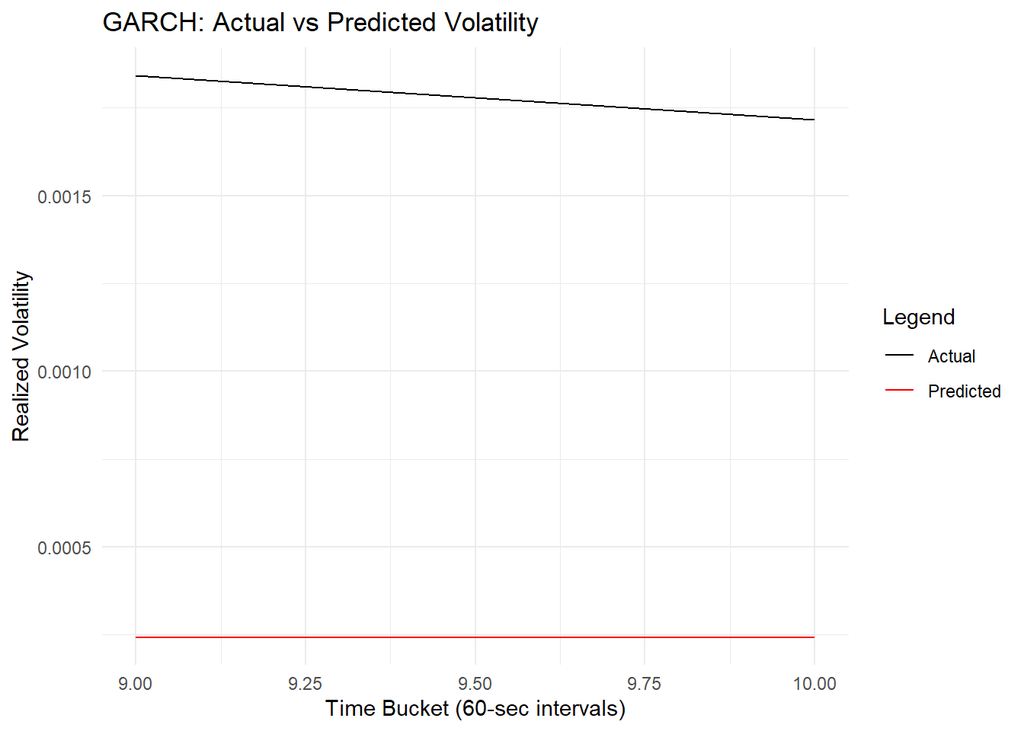

```r
# GARCH
garch_spec <- ugarchspec(
  variance.model = list(model = "sGARCH", garchOrder = c(1, 1)),
  mean.model = list(armaOrder = c(0, 0), include.mean = TRUE),
  distribution.model = "norm"
)
# fit GARCH on log returns of time_id 1 over first 480 seconds
garch_fit <- ugarchfit(
  spec = garch_spec,
  data = log_r1[[1]] %>% filter(time <= 480) %>% pull(log_return),
  solver = 'hybrid'
)
# predict
garch_fc <- ugarchforecast(garch_fit, n.ahead = nrow(vol.val[[1]]))
sigma_forecast <- sigma(garch_fc)

GARCH.pred <- rep(mean(sigma_forecast), nrow(vol.val[[1]]))
df_garch <- data.frame(
  time_bucket = vol.val[[1]]$time_bucket,
  Actual = vol.val[[1]]$volatility,
  Predicted = GARCH.pred
)
ggplot(df_garch, aes(x = time_bucket)) +
  geom_line(aes(y = Actual, color = "Actual")) +
  geom_line(aes(y = Predicted, color = "Predicted")) +
  labs(title = "GARCH: Actual vs Predicted Volatility",
       x = "Time Bucket (60-sec intervals)",
       y = "Realized Volatility") +
  scale_color_manual(name = "Legend", values = c("Actual" = "black", "Predicted" = "red")) +
  theme_minimal()
```

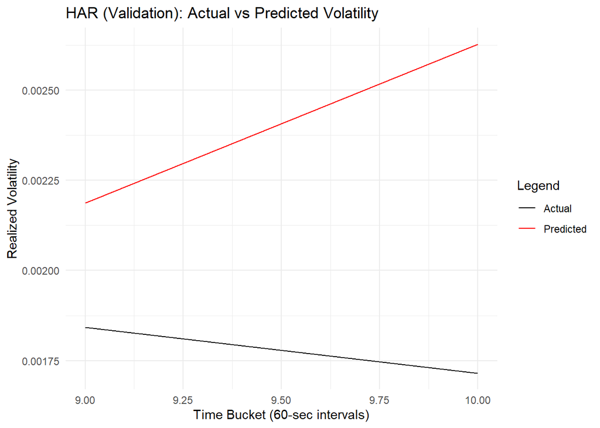

```r
# HAR
har_data <- vol[[1]] %>%
  arrange(time_bucket) %>%
  mutate(vol_lag1  = lag(volatility, n = 1),
         vol_last3 = rollmean(volatility, k = 3, fill = NA, align = "right"),
         vol_last5 = rollmean(volatility, k = 5, fill = NA, align = "right")) %>%
  filter(!is.na(vol_lag1) & !is.na(vol_last3) & !is.na(vol_last5))

# out-of-sample
n_total <- nrow(har_data)
n_train <- floor(0.8 * n_total)
har_train <- har_data[1:n_train, ]
har_val <- har_data[(n_train + 1):n_total, ]

# fit HAR on training set
har_model_val <- lm(volatility ~ vol_lag1 + vol_last3 + vol_last5, data = har_train)
har_val <- har_val %>%
  mutate(predicted_vol = predict(har_model_val, newdata = har_val))
ggplot(har_val, aes(x = time_bucket)) +
  geom_line(aes(y = volatility, color = "Actual"), na.rm = TRUE) +
  geom_line(aes(y = predicted_vol, color = "Predicted"), na.rm = TRUE) +
  labs(title = "HAR (Validation): Actual vs Predicted Volatility",
       x = "Time Bucket (60-sec intervals)",
       y = "Realized Volatility") +
  scale_color_manual(name = "Legend", values = c("Actual" = "black", "Predicted" = "red")) +
  theme_minimal()
```

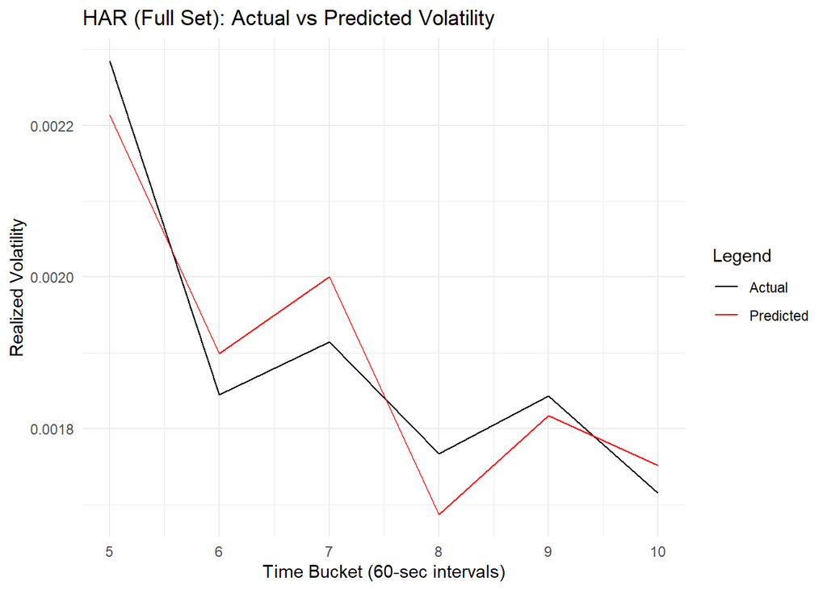

```r
# in-sample
har_model_full <- lm(volatility ~ vol_lag1 + vol_last3 + vol_last5, data = har_data)
har_data <- har_data %>%
  mutate(fitted_vol = har_model_full$fitted.values)
ggplot(har_data, aes(x = time_bucket)) +
  geom_line(aes(y = volatility, color = "Actual"), na.rm = TRUE) +
  geom_line(aes(y = fitted_vol, color = "Predicted"), na.rm = TRUE) +
  labs(title = "HAR (Full Set): Actual vs Predicted Volatility",
       x = "Time Bucket (60-sec intervals)",
       y = "Realized Volatility") +
  scale_color_manual(name = "Legend", values = c("Actual" = "black", "Predicted" = "red")) +
  theme_minimal()
```

```r
# evaluation metrics
evaluate_model <- function(actual, predicted) {
  rmse <- sqrt(mean((actual - predicted)^2))
  mae  <- mean(abs(actual - predicted))
  r2   <- 1 - sum((actual - predicted)^2) / sum((actual - mean(actual))^2)
  mape <- mean(abs((actual - predicted) / actual)) * 100
  return(list(RMSE = rmse, MAE = mae, R2 = r2, MAPE = mape))
}

# LM
lm_eval <- evaluate_model(vol.val[[1]]$volatility, lm_val_predictions)

# HAR (Out-of-Sample)
har_eval <- evaluate_model(har_val$volatility, predict(har_model_val, newdata = har_val))

# HAR (In-Sample)
har_common_eval <- evaluate_model(har_data$volatility, predict(har_model_full, newdata = har_data))

# GARCH
garch_eval <- evaluate_model(vol.val[[1]]$volatility, GARCH.pred)

models_eval <- data.frame(
  Model = c("Linear Regression", "HAR (Out-of-Sample)", "HAR (In-Sample)", "GARCH"),
  RMSE  = c(lm_eval$RMSE, har_eval$RMSE, har_common_eval$RMSE, garch_eval$RMSE),
  MAE   = c(lm_eval$MAE, har_eval$MAE, har_common_eval$MAE, garch_eval$MAE),
  R2    = c(lm_eval$R2, har_eval$R2, har_common_eval$R2, garch_eval$R2),
  MAPE  = c(lm_eval$MAPE, har_eval$MAPE, har_common_eval$MAPE, garch_eval$MAPE)
)
print(models_eval)
```

```
                Model         RMSE          MAE           R2      MAPE
1   Linear Regression 3.603229e-04 3.506706e-04  -31.0426178 19.567761
2 HAR (Out-of-Sample) 6.891932e-04 6.279509e-04 -116.2266048 35.910781
3     HAR (In-Sample) 6.295698e-05 5.885158e-05    0.8847213  3.093979
4               GARCH 1.537604e-03 1.536286e-03 -582.4898046 86.328804
```

### eGARCH Model

[figure not shown]

```r
egarch_spec <- ugarchspec(
  variance.model = list(model = "eGARCH", garchOrder = c(1, 2)),
  mean.model     = list(armaOrder = c(0, 0), include.mean = TRUE),
  distribution.model = "norm"
)

# fit the eGARCH Model
data_for_fit <- log_r1[[1]] %>% filter(time <= 480) %>% pull(log_return)

egarch_fit <- ugarchfit(
  spec = egarch_spec,
  data = data_for_fit,
  solver = "hybrid"
)

n_ahead <- nrow(vol.val[[1]])
egarch_fc <- ugarchforecast(egarch_fit, n.ahead = n_ahead)
sigma_forecast <- sigma(egarch_fc)
egarch_pred <- rep(mean(sigma_forecast), n_ahead)

# evaluate
df_egarch <- data.frame(
  time_bucket = vol.val[[1]]$time_bucket,
  Actual      = vol.val[[1]]$volatility,
  Predicted   = egarch_pred
)

ggplot(df_egarch, aes(x = time_bucket)) +
  geom_line(aes(y = Actual, color = "Actual")) +
  geom_line(aes(y = Predicted, color = "Predicted")) +
  labs(title = "eGARCH: Actual vs Predicted Volatility",
       x = "Time Bucket (30-sec intervals)",
       y = "Realized Volatility") +
  scale_color_manual(name = "Legend", values = c("Actual" = "black", "Predicted" = "red")) +
  theme_minimal()
```

```r
egarch_eval <- evaluate_model(vol.val[[1]]$volatility, egarch_pred)
print(egarch_eval)
```

```
$RMSE
[1] 0.001524415

$MAE
[1] 0.001523086

$R2
[1] -572.5229

$MAPE
[1] 85.58593
```

## Reference

Peiris, S., & Hunt, R. (2023). Revisiting the Autocorrelation of Long Memory Time Series Models. Mathematics, 11(4), 817. https://doi.org/10.3390/math11040817

Wickham H (2016). ggplot2: Elegant Graphics for Data Analysis. Springer-Verlag New York. ISBN 978-3-319-24277-4, https://ggplot2.tidyverse.org.

Wickham H, François R, Henry L, Müller K, Vaughan D (2023). dplyr: A Grammar of Data Manipulation. R package version 1.1.4, https://github.com/tidyverse/dplyr, https://dplyr.tidyverse.org.

Galanos A (2024). rugarch: Univariate GARCH models.. R package version 1.5-3.

Zeileis A, Grothendieck G (2005). “zoo: S3 Infrastructure for Regular and Irregular Time Series.” Journal of Statistical Software, 14(6), 1–27. doi:10.18637/jss.v014.i06.

Wickham H, Averick M, Bryan J, Chang W, McGowan LD, François R, Grolemund G, Hayes A, Henry L, Hester J, Kuhn M, Pedersen TL, Miller E, Bache SM, Müller K, Ooms J, Robinson D, Seidel DP, Spinu V, Takahashi K, Vaughan D, Wilke C, Woo K, Yutani H (2019). “Welcome to the tidyverse.” Journal of Open Source Software, 4(43), 1686. doi:10.21105/joss.01686.

Canvas, U. (2025). The University of Sydney - Sign In. Sydney.edu.au. https://canvas.sydney.edu.au/courses/65141/pages/week-3-financial-time-series-data?module_item_id=2667174